# Clean butterfly network data

# Introduction

In our empirical studies, we required participants to learn about the same artificial social network (i.e., the “butterfly” network, so named because it resembles a butterfly with its wings extended). Here, we’re going to clean/compute information about the network that we might find useful during later analysis.

# Initialize

Loading libraries and custom scripts…

```r
# For reproducibility...
set.seed(sum(utf8ToInt("bullet with butterfly wings")))

library(tidyverse)
library(here)
```

```r
library(igraph)
library(tidygraph)
library(ggraph)

source(here("code", "utils", "network_utils.R"))
```

Loading data…

```r
walk_learn <- here("data", "butterfly-behavior", "walk_learn.csv") %>%
  read_csv(show_col_types = FALSE)

pair_learn <- here("data", "butterfly-behavior", "pair_learn.csv") %>%
  read_csv(show_col_types = FALSE)
```

# Build network

Having a graph of the network is useful, as it means that we can easily extract out an “adjacency list” that can help us model how various learning strategies produce different kinds of network representations. The easiest way to build a network is with an edgelist and nodelist. Both studies use the exact same network structure, so we could in principle use either to do this.

The following code is slightly overkill for what we want to do (i.e. assign stable numeric IDs to each node), as the nodes are already identified by a numeric ID in the paired associates study. But, should this change in the future (such that the nodes are alternatively identified by a text ID), this code is flexible enough to allow that without further modification.

```r
# Recover edgelist from learning trials
netrep_edgelist <- pair_learn %>%
  filter(sub_id == 1) %>%
  mutate(
    from_sorted = if_else(from < to, from, to),
    to_sorted = if_else(from < to, to, from)
  ) %>%
  select(
    from = from_sorted,
    to = to_sorted
  ) %>%
  distinct() %>%
  arrange(from, to)

# Use edgelist to create nodelist
netrep_nodelist <- bind_rows(
  netrep_edgelist %>% select(name = from),
  netrep_edgelist %>% select(name = to)
) %>%
  distinct() %>%
  arrange(name) %>%
  mutate(node_id = row_number())
```

Now that we’ve got those lists in hand, we can now create a `tbl_graph` network representation…

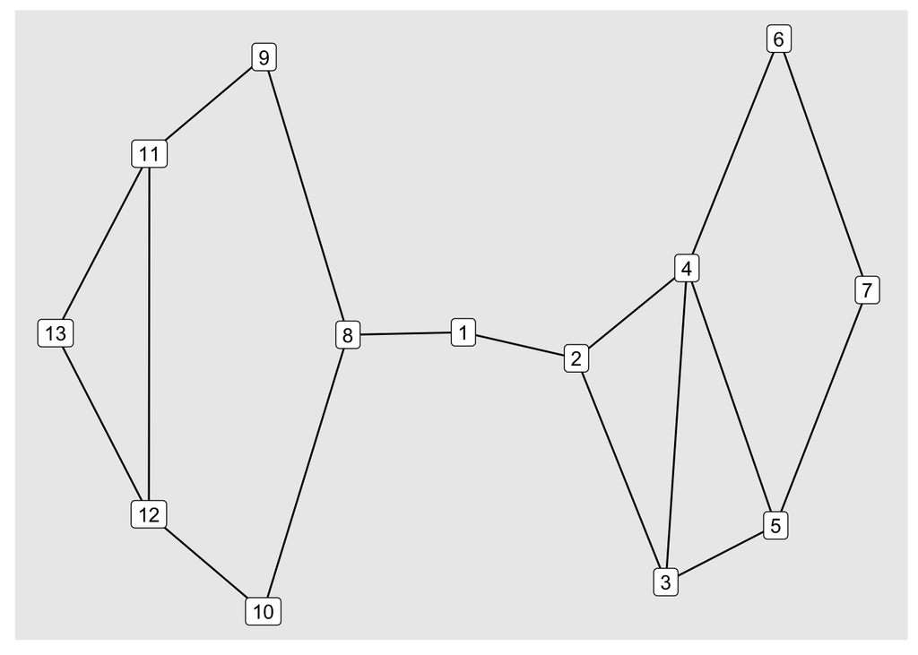

```r
netrep_network <- tbl_graph(
  nodes = netrep_nodelist,
  edges = netrep_edgelist,
  directed = FALSE
)

# Get adjlist from network
netrep_adjlist <- netrep_network %>%
  graph_to_adjlist()

# Convert adjlist to adjacency matrix
netrep_adjmat <- netrep_adjlist %>%
  arrange(from, to) %>%
  pivot_wider(names_from = to, values_from = edge) %>%
  select(-from) %>%
  as.matrix()

# Plot what network looks like
netrep_network %>%
  ggraph(layout = "stress") +
  geom_edge_link() +
  geom_node_label(aes(label = name))
```

# Centrality

We may be interested in knowing various centrality metrics. It is safe to ignore the warning message `'nobigint' is deprecated since igraph 1.3 and will be removed in igraph 1.4`.

```r
netrep_centrality <- netrep_network %>%
  mutate(
    Degree = centrality_degree(),
    Between = centrality_betweenness(directed = FALSE),
    Eigen = centrality_eigen(),
    Closeness = centrality_closeness()
  ) %>%
  as_tibble()
```

```
## Warning in betweenness(graph = graph, v = V(graph), directed = directed, :
## 'nobigint' is deprecated since igraph 1.3 and will be removed in igraph 1.4
```

# Features

The network structure (nodes + edges) is the same for all participants, but different stimuli were shown to different participants. So, let’s fill in the details of some social features (race + gender) that we might want to look at later.

```r
walk_features <- bind_rows(
  walk_learn %>% select(sub_id, name = from, face_id = from_face),
  walk_learn %>% select(sub_id, name = to, face_id = to_face)
) %>%
  distinct() %>%
  arrange(sub_id, name) %>%
  left_join(netrep_nodelist, by = "name") %>%
  mutate(
    race = str_sub(face_id, 5, 5),
    gender = str_sub(face_id, 6, 6)
  ) %>%
  mutate(
    race_id = case_when(
      race == "A" ~ 1,
      race == "B" ~ 2,
      race == "L" ~ 3,
      race == "W" ~ 4
    ),
    race = case_when(
      race == "A" ~ "asian",
      race == "B" ~ "black",
      race == "L" ~ "latinx",
      race == "W" ~ "white"
    )
  ) %>%
  mutate(
    gender_id = case_when(
      gender == "F" ~ 1,
      gender == "M" ~ 2
    ),
    gender = case_when(
      gender == "F" ~ "female",
      gender == "M" ~ "male"
    )
  )

pair_features <- bind_rows(
  pair_learn %>% select(sub_id, name = from, face_id = from_face),
  pair_learn %>% select(sub_id, name = to, face_id = to_face)
) %>%
  distinct() %>%
  arrange(sub_id, name) %>%
  left_join(netrep_nodelist, by = "name") %>%
  mutate(
    race = str_sub(face_id, 5, 5),
    gender = str_sub(face_id, 6, 6)
  ) %>%
  mutate(
    race_id = case_when(
      race == "A" ~ 1,
      race == "B" ~ 2,
      race == "L" ~ 3,
      race == "W" ~ 4
    ),
    race = case_when(
      race == "A" ~ "asian",
      race == "B" ~ "black",
      race == "L" ~ "latinx",
      race == "W" ~ "white"
    )
  ) %>%
  mutate(
    gender_id = case_when(
      gender == "F" ~ 1,
      gender == "M" ~ 2
    ),
    gender = case_when(
      gender == "F" ~ "female",
      gender == "M" ~ "male"
    )
  )
```

# Export

```r
if (dir.exists(here("data", "butterfly-network")) == FALSE) {
  dir.create(here("data", "butterfly-network"))
}

netrep_adjlist %>%
  write_csv(here("data", "butterfly-network", "adjlist.csv"))

netrep_adjmat %>%
  write.table(
    here("data", "butterfly-network", "adj_matrix.txt"),
    row.names = FALSE,
    col.names = FALSE
  )

netrep_edgelist %>%
  write_csv(here("data", "butterfly-network", "edgelist.csv"))

netrep_nodelist %>%
  write_csv(here("data", "butterfly-network", "nodelist.csv"))

netrep_centrality %>%
  write_csv(here("data", "butterfly-network", "centrality.csv"))

walk_features %>%
  write_csv(here("data", "butterfly-network", "features_walk.csv"))

pair_features %>%
  write_csv(here("data", "butterfly-network", "features_pair.csv"))
```